# Dreaming of Flying When Grounded: Occupational Identity and Occupational Fantasies of Furloughed Airline Pilots

Converted from PDF `Fraher-FurloughedPilotIdentity-2014-JMS.pdf` · 26 pages · anchors: page `#pN`, block `#pN-bK`

Page 1

### **Dreaming of Flying When Grounded: Occupational Identity and Occupational Fantasies of Furloughed Airline Pilots**

### **Amy L. Fraher and Yiannis Gabriel**

*Independent Researcher; University of Bath*

ABSTRACT This article analyses the effects of job loss on the occupational identities of a group of United States pilots, laid off (or ‘furloughed’) twice by their employer in the decade following 9/11. Using a narrative methodology, the paper examines how the childhood dream of flying, referred to as the Phaëthon dream, serves as an identity anchor that sustained their occupational identities. When the circumstances of the aviation industry (restructuring, outsourcing, and downsizing) led to extensive lay-offs, this identity anchor functioned in two contrasting ways. Some pilots moved on to retrain and start new careers, without abandoning their occupational identities or relinquishing the dream of flying. Another group of pilots, however, were stuck in occupational limbo waiting to be recalled by their employer, unwilling to forsake this dream and refusing to contemplate a move that would decisively take them out of their pilot seats. The paper’s contribution lies in theorizing how a dream originating in childhood, linked to a long-standing archetype of flying and subsequently hardened into a shared occupational fantasy, acts as an identity anchor and how this shapes responses to the trauma of job loss. The paper concludes by linking the Phaëthon dream to its mythological counterpart in order to highlight its enduring, shared, and unconscious character.

**Keywords:** airlines, identity anchors, job loss, narrative, occupational fantasy, occupational identity, pilots, unemployed professionals

In periods of economic recession, when other companies shed employees, airlines ‘park planes’. By some estimates, more than 2300 planes were parked by US airlines in the summer of 2009. What is less often discussed than the fate of planes gathering dust in the desert is the fate of the pilots who are laid off at the same time. The term ‘furlough’ is widely used in the aviation industry to designate the state of a pilot who is laid off for an indeterminate period, waiting to be recalled in strict order of seniority, if and when times get better. Furloughs, or, in airline parlance, spending time ‘on the street’, have long been part of the price pilots have to pay for the volatility of their industry.

*Address for reprints*: Amy L. Fraher, 1356 Couples Circle, Fairfield, CA 94533, USA (amylfraher@gmail.com).

© 2014 John Wiley & Sons Ltd and Society for the Advancement of Management Studies

*Journal of Management Studies* 51:6 September 2014 doi: 10.1111/joms.12081

Page 2

The September 11th 2001 (9/11) terrorist attacks had a dramatic impact on the aviation industry, precipitating extensive restructuring and employee lay-offs. Between 9/11 and 2010, nearly every major US air carrier declared bankruptcy and 200,000 airline employees lost their jobs including over 14,000 pilots at the seven major carriers, a 29 per cent reduction in force (US Department of Transportation 2010). Although some employees took early retirement or left on their own accord, most were furloughed with the right to return to work, if and when, their airline needs them again.

This paper is based on the experiences of a group of pilots who were furloughed twice: once immediately after 9/11 and then again in the late 2000s. If the first furlough was seen as the inevitable result of a national calamity, the second furlough, coming on a wave of industry retrenchment, downsizing, and restructuring, presented them with grave challenges to their occupational identities, their careers, and even their livelihoods. This article examines these pilots’ responses to job loss and its impact on their occupational identities. Occupational identity is constructed and sustained within a community of workers as they deploy various rhetorical and other devices to differentiate themselves from other occupational groups and support their individual identities (Ashcraft, 2007; Fine, 1996). Occupational identity can then be viewed as a narrative web that nestles in the identity narratives of each member of the community, blending elements from their profession’s past successes and trials, present challenges, and future aspirations and hopes. As we will show in this paper, occupational identity also incorporates various idealized and other images and myths, which can be regarded as institutionalized occupational fantasies that shape the outlooks and experiences of the occupation’s members (Fraher, 2004).

Job loss leads to severe challenges to occupational identity. Occupational groups usually resort to new narrative and rhetorical means to account for deep changes that affect them (Ashcraft, 2005, 2007). Individuals too seek to develop new identity narratives that account for job loss and indicate a way forward (Parry, 2003). The ways in which relatively privileged professional groups respond to challenges to their occupational identity, especially when these involve mass lay-offs and drastic worsening of working conditions, have not been widely covered in the literature (Cameron, 2001; Kitay and Wright, 2007; Petriglieri, 2011; Tedeschi and Calhoun, 2004). This prompted us to focus our inquiry on the following questions: What are the demands that furloughs make on pilots’ occupational identities and how do they respond to these demands? How, if at all, do they seek to reshape their identities following lay-offs? Do furloughs undermine their identification with their employer or the industry (He and Baruch, 2010)? The unique contribution of this paper lies in showing how pilots, as a group of privileged professionals, respond to job loss by constructing narratives that help sustain their occupational identities. A crucial element of these narratives, and one whose ramifications have not been adequately recognized in the past, is their connection to a specific childhood dream, an image of themselves flying in the skies, free and uninhibited. We propose that such dreams or ‘shared occupational fantasies’ act as occupational identity anchors that motivate members, sustain them through periods of hardship, and inspire them to deal with adversities. However, for at least some members of a profession, such occupational fantasies become a severe obstacle, acting as a kind of addiction that

Occupational Identity of Furloughed Airline Pilots 927

© 2014 John Wiley & Sons Ltd and Society for the Advancement of Management Studies

Page 3

hinders flexibility and inhibits adaptation to changing circumstances – in short, they become self-constructed cages from which members are unable to escape.

The dream of flying, often originating in early childhood, exercises a powerful influence on pilots, and, in defending it, they are prepared to endure many privations. We shall refer to this as the ‘Phaëthon dream’, after the mythological character who was obsessed since childhood with flying the chariot of his father Helios, the sun god, and we will argue that this dream constitutes a shared fantasy subscribed to by many members of the piloting profession. An attachment to childhood dreams is a feature that pilots may share with members of some other occupational groups who describe their work as ‘a calling’ or ‘labour of love’, such as orchestral musicians (Faulkner, 1973), members of elite military groups (Thornborrow and Brown, 2009), academics (Clarke et al., 2012), and zookeepers (Bunderson and Thompson, 2009), for whom ‘deeply meaningful work can become a double-edged sword’ (Bunderson and Thompson, 2009, p. 32). The implications of this study are quite extensive, given that pilots, along with many other previously privileged professional groups, are currently finding themselves deeply affected by the demands made by today’s flexible capitalism, with its outsourcing and deskilling tendencies and its ruthless pursuit of the bottom line (Brown, 2006; Gabriel, 2004a; Humphreys and Brown, 2002; Maguire and Phillips, 2008; Stavrou and Ierodiakonou, 2011).

#### **OCCUPATIONAL IDENTITIES**

The concept of identity is currently emerging as something of a ‘master signifier’ in many areas of social and organizational studies (Alvesson et al., 2008). Studies of consumption, professionalization, labour process, ethnicity, and gender along with numerous others are inexorably drawn to identity and, as soon as they discover it, begin to revolve around it. There are many reasons for the current popularity of the concept of identity but it seems to us that it partly lies in its ability to mutate and fragment, to grow and shrink, to incorporate and shed elements, and to become a terrain rife for crises, struggles, and fantasies. Unlike connate terms, like self and subjectivity, identity is not tainted by philosophical assumptions of sovereignty and rationality. It easily accommodates a social component (Alvesson, 2010; Alvesson et al., 2008; Watson, 2008; Ybema et al., 2009) while preserving the fundamental qualities of sameness and uniqueness across time.

Identity, in particular, and the various struggles that surround it are well attuned to the temporary, fluid, and porous qualities of late modernity (Coupland and Brown, 2012). Many organizations today seem to make ambiguous or contradictory demands on people, which are well catered for by the concept of identity (Alvesson, 2001). On the one hand, for example, organizations frequently demand that employees go beyond the mere execution of their tasks by embracing their values, brand, and narratives – in short, they expect employees to identify with the organization. On the other hand, organizations steadfastly refuse to offer employees the security and permanence of stable employment, by constantly looking for opportunities to outsource and off-shore (Lippmann, 2008). The project of identity describes well the plight of the individuals who are frequently on the move, who are often called to reinvent themselves, the individuals who are free from obligations of life-long loyalty to an employer but who are expected to fully identify with

A. L. Fraher and Y. Gabriel 928

© 2014 John Wiley & Sons Ltd and Society for the Advancement of Management Studies

Page 4

their organization for indeterminate periods of time (Gabriel, 2005). The concept also serves well those interested in the ways that contemporary capitalism creates disciplined and self-disciplined employees who, in seeking to maintain their identities, go beyond the call of duty (Alvesson and Robertson, 2006; Clarke et al., 2009).

One of the attractive qualities of identity has been its easy ‘narrativization’ (Brown and Humphreys, 2002), in other words the ease with which it lends itself to being approached as the product of different stories and narratives that people tell about themselves (see, among others, Bruner, 1995; Giddens, 1991; Ibarra and Barbulescu, 2010; McAdams et al., 2006; Polkinghorne, 1996). Experiences, such as seminal events in a person’s life – academic qualifications, job moves, severe illnesses and so forth – by themselves do not constitute occupational identity. When, however, such experiences are emplotted (‘storied’) in meaningful patterns, with triumphs and reversals, struggles and disappointments, they then become the basis of a narrative identity which people then proceed to ‘live out’ (Sims, 2003). Such narrative identities are always provisional and reflexive.

They are provisional in that the story of one’s life is constantly being re-created, sometimes in small and sometimes in major ways (Ibarra, 1999). What was a success in an early story (e.g., a promising job move) may turn out to be a poisoned chalice in a later one (e.g., a move into a toxic work environment); what seemed like a disaster in an early story (e.g., being fired) may turn out to be an opportunity in a later one (retraining and vastly enhanced work prospects). They are also reflexive – the author of the story and the story’s central character co-create each other. At every moment the storyteller creates a protagonist, whose predicaments redefine the storyteller. In telling the story of our lives, we make sense of past events and create a person living in the present as a continuation of the story. It is in this way that experience becomes digested and meaningful.

In addition to being reflexive and provisional, occupational identities have the ability to mutate across different patterns or templates. For example, Fine (1996) found that the occupational identities of chefs incorporated nuanced images of themselves as scientists, artists, accountants, surgeons, psychiatrists, and handymen in a complex and malleable conceptualization of their professional self. These bundles of rhetorical images were provisional, situationally dependent and, like self-constructed narratives, not necessarily consistent with each other. Similarly, Kitay and Wright (2007) observed how management consultants use rhetoric and imagery to construct a complex and often contradictory occupational identity as professionals, prophets, business partners, and service workers. In some ways, these strategies helped consultants manage the nomadic aspects of their job that require them to perpetually ‘move on’. Continuing the exploration of ‘moving on’, Das (2012) studied worker turnover at Indian call centres and found that when employees considered leaving, three critical identities emerged as salient: national, organizational, and occupational. Like Johnson et al. (2006), Das found employees more committed to their occupational identity, than to their employer or the organizational identity.

Other explorations of occupational identity and organizational commitment have stretched the concept to include, beyond lived experiences, fantasies or ‘unlived experiences’. Thus Thornborrow and Brown (2009), who studied British paratroopers, argued that their occupational identities revolved around an idealized conception of what it means to be a member of an elite regiment. Such occupational identities entail an

Occupational Identity of Furloughed Airline Pilots 929

© 2014 John Wiley & Sons Ltd and Society for the Advancement of Management Studies

Page 5

‘aspirational component’ which requires the constant rewriting of life’s experiences in a genuine attempt to reach the ideal (p. 370). Similarly, Faulkner (1973, p. 337) noted ‘career footholds’ which helped orchestral musicians assess whether they were ‘making it’ or not by evaluating where they were located – in what seat, in which ensemble within which organization – and how long it took them to get there.

In this way, occupational identity can be seen to include an ‘ideal’ which is substantially shaped by social and organizational discourses. Aspirational identity retrieves an important insight of an earlier generation of organizational scholars (Gabriel, 1993; Hirschhorn and Gilmore, 1989; Schwartz, 1987) who used the concept ‘organizational ideal’ to describe the idealized qualities of organizations, such as their power, opulence, prestige, technical excellence and so forth. These qualities can become part of an individual’s ego ideal even before he or she is admitted to the organization and hence a provisional part of his or her occupational identity. Through this ideal, individuals’ occupational identities become intertwined with organizational identities (Cornelissen, 2002), something especially important in the case of pilots who identify extensively with their employer (Lewis, 2008), and, like orchestral musicians (Faulkner, 1973), associate personal success with a physical rise up a very visible hierarchy such as what cockpit seat, in which airplane, at what airline.

Another interesting development in current explorations of identity is proposed by Obodaru (2012), who argues that when people talk about their ‘selves’, they are referring not only to past and present experiences or future aspirations, but also to all those possibilities, the ‘might have beens’ in their lives that, for some reason or other, they never got a chance to live out. Such unlived but very ‘real’ possibilities may include opportunities missed, accidents avoided, obstacles overcome, or decisions that might have gone a different way. The influence of these unlived possibilities may refuse to diminish and may well continue to shape or even define people’s occupational identities long afterwards. Like Thornborrow and Brown, Obodaru emphasized that dreams and fantasies are vital parts of the occupational identities of many people, something that as we shall see presently is vitally important in understanding the plight of pilots when they are furloughed.

#### **Job Loss**

Job loss is a life event that makes extensive demands on people affected by it and their close circles (Fineman, 1979; Jahoda, 1982; Seabrook, 1982; Warr and Jackson, 1984). While the severity of its effects varies, it makes deep financial, family, and social demands, and also prompts various psychological responses and adjustments to a person’s occupational identity (Ainsworth and Hardy, 2009; Ezzy, 2001; Gabriel et al., 2010; Leana and Ivancevich, 1987). In recent years, there has been an increased academic interest in job loss among professional employees, partly as a result of what is variously described as the ‘new economy’ (Lippmann, 2008) or ‘new risk economy’ (Mendenhall et al., 2008) with its emphasis on flexible employment patterns and contingent workforces (Clarke et al., 2009; Matusik and Hill, 1998). Under this flexible economy, managers and professionals are as likely to be victims of downsizing, offshoring, mergers, and acquisitions as blue-collar employees.

A. L. Fraher and Y. Gabriel 930

© 2014 John Wiley & Sons Ltd and Society for the Advancement of Management Studies

Page 6

Various studies have explored the psychological effects of job loss for such people. Although Zikic and Richardson (2007) found that job loss can be a ‘blessing in disguise’ for some middle managers, prompting them to move on in new directions, Letkemann (2002) paints a bleak picture of psychological isolation, withdrawal, and stigmatization. A considerable body of literature on post-traumatic growth (Calhoun and Tedeschi, 2004; Davis et al., 1998; Maitlis, 2012; Neimeyer, 2001; Tedeschi and Calhoun, 2004) has proposed that some individuals seek to restore their ‘positive identities’ by concluding a mourning process that leads to reconciliation with adversity and a willingness to open a new chapter in their lives. Our approach is closer to that of Gabriel et al. (2010), who identified different narratives through which unemployed professionals seek to come to terms with job loss without, however, being able to completely disconnect them from their loss. Even those willing and able to open new chapters in their lives embark on an enduring quest in which the trauma of unemployment plays an active part, even if it does not define their identity.

Pilots represent a critical occupational group to study in connection with the demands made by job loss on their occupational identities. As a profession, they have long enjoyed prestige and, in some cases, financial rewards on a par with those of doctors and lawyers. Yet, they have been liable to periodic furloughs which effectively place them in a psychological limbo-land of indeterminate duration (Hopkins, 1971). This presents them with a dilemma between waiting passively to be recalled, possibly with the aid of stop-gap, poorly paid, temporary employment, versus moving on and exploring new employment and career opportunities. Furthermore, in addition to cyclical effects, the industry has been subject to extensive restructuring with many famous brands going out of business, others merging, and others undergoing drastic reorganization, off-shoring or outsourcing many of their operations (Gittell et al., 2004). Prompted by the slump that followed 9/11, salaries and terms of employment for pilots in many of the leading American airlines declined substantially, a trend which was accelerated further by the 2008 economic crisis (Fraher, 2012; Franke and John, 2011; Gittell et al., 2004).

Pilots can plausibly be viewed as an occupational group whose predicament, including periods of unemployment, declining financial and symbolic rewards (Ashcraft, 2005, 2007), and a propensity for their work to be deskilled, outsourced, or off-shored, makes them something of a vanguard in the new flexible economy. What, however, makes pilots such an intriguing profession to study in connection with the preceding discussion is their very extensive identification with flying, their fellow professionals, and even with their airline. These factors are liable to be severely tested when a pilot is furloughed and unable to fly, physically separated from airplanes and fellow aircrew, thereby making it difficult to maintain a sense of occupational identification.

#### **THE FIELD RESEARCH**

The field material presented in this paper was collected as part of a larger study of the post-9/11 airline industry between September 2010 and July 2011 which included a survey of 127 pilots, 33 of whom were subsequently interviewed. A third round of field research examined in depth the experiences of ten pilots, nine men and one woman, who

Occupational Identity of Furloughed Airline Pilots 931

© 2014 John Wiley & Sons Ltd and Society for the Advancement of Management Studies

Page 7

were all ‘double furloughees’. Although the earlier rounds offered valuable contextual material and enabled us to test our inferences and interpretations, the core of this paper relies on these ten who had all been employees of a major US airline (referred to as ‘Vimanas’) and ranged between mid-thirties and early fifties in age.

Interviews were recorded and transcribed, lasting on average 68 minutes and yielding almost 110,000 words of transcript. Although an interview guide was used, the interview was non-directive, allowing respondents to co-determine the direction and flow of the conversation. Respondents were asked open-ended questions and encouraged to talk about their life, feelings, family, and work. The focus was directed towards understanding meaning from the point of view of each respondent. Although none of them were personally known to the researchers prior to this study, we recognize that the sample was not randomly selected nor were the researchers free of feelings and assumptions of their own about the topic of their inquiry.

The extensive nature of this research was only possible because of the first author’s experience as a Vimanas pilot from 1997 to 2004, after which she voluntarily resigned to pursue an academic career. This industry experience generated the research questions and no doubt affected the interpretation of the findings by providing an experientially based lens by which to understand these very industry-specific narratives. To reduce the potential of simply projecting pre-existing views onto the research material, the two authors engaged in extensive discussions and cross-fertilization, in which the first author’s detailed and personal knowledge of the aviation industry were balanced out by the second author’s readings of the research material as an outsider. The resulting collaboration sought to cross-fertilize the first author’s insider knowledge of the piloting profession and the aviation industry with the second author’s substantive theoretical and methodological expertise from a position outside the aviation industry. In this way, the processing of the empirical material can be described as dialogical – numerous nuances, as well as the industry jargon present in the interviews would have been incomprehensible without the first author’s insider understanding; conversely, some of the assumptions unquestioningly made by insiders may not have been problematized without the second author’s more detached standing.

The first author’s prior airline experience enabled her to easily get in touch with pilots via existing on-line networks but also, far more importantly, to engage with them as a peer, eliciting responses of an honesty and depth that would have been impossible for any outsider. All of these pilots reported that the piloting profession was widely misunderstood by the public and the media and acknowledged that they rarely, if ever, spoke to any outsiders. As one of them said:

[I] only [talk] with fellow pilots who have been furloughed. You can’t talk to anyone else unless it’s another furloughed pilot . . . no one else understands. They don’t. They say things that are so stupid . . . I don’t ever discuss [being unemployed] with anybody other than a pilot or somebody who’s in the know. [Anthony]

This reluctance is not uncommon; Newman (1988, p. x) found that people who have lived through job loss and ‘downward mobility’ are often ‘so bewildered by their fate that they find it hard to explain to themselves, let alone others, what has befallen

A. L. Fraher and Y. Gabriel 932

© 2014 John Wiley & Sons Ltd and Society for the Advancement of Management Studies

Page 8

them’. The questions asked in the interviews concerned the pilots’ motives for their choice of job and career, their experiences as pilots, and during the two periods of furlough, their views on the company and the aviation industry, their hopes for the future, and the advice they would give to a young person considering a career as a pilot. A substantial number of stories were collected, many of whom had an intensely personal character.

Equally important to drawing highly personal and confessional views and stories, the first author’s prior experience as a pilot was a valuable resource in the subsequent interpretation and analysis of the material. Inevitably what our respondents disclosed must be viewed in the context of a conversation with a professional peer, moreover one who had ‘moved on’ in their terms to a new career as an academic. We believe that the discussion of the field material we shall offer presently justifies the conclusion that in talking to a fellow professional rather than an academic researcher, our respondents attained a considerable level of critical self-examination and reflexivity. They confided, they probed, frequently they vented. They were not hesitant in expressing strong views or in revealing ambivalence and inconsistency. This offered us valuable insights into some of the conflicting emotions and narratives guiding their responses.

The pilots we interviewed were keen to tell their stories; they were generally articulate, outspoken, and believed that their plight could provide useful learning both to researchers but also to aspirant future pilots. Like many professionals discussing their professional lives with a fellow professional, they responded with enthusiasm to many questions and, at the end of the interviews, raised numerous questions of their own. The research could easily have extended to double the number of respondents or more, but we felt that a critical mass of material had already been collected to enable us to draw some consistent and reliable conclusions.

Extending the number of respondents would have also weakened our way of working with the data, which involved listening to the recordings repeatedly in addition to reading the transcripts, constantly drawing comparisons between different respondents and between their own interpretations of the data. Instead of formally coding the data, we probed the data to tease out tensions, irregularities, and ambiguities. It is our view that this way of ‘working with the data’ provides a valid and valuable alternative to using coding software which can easily lapse into mechanical routine. Instead, our approach was iterative, discursive, and reflexive, the latter apparent in our continuous attempt to assess how our own interests and prejudices may be surfacing in our interpretations and inferences, something that often goes unnoticed when researchers undertake formal data coding. Throughout our discussions of the empirical material, we constantly iterated between our data and the findings of other studies, as well as between data and theoretical formulations (see Figure 1).

Our overall approach was consistent with the emerging reflexive approach to the conduct of qualitative inquiry, one in which researchers seek to question their own values and assumptions, their active role in the field work, and the stake they have in the findings and interpretations (Alvesson and Sköldberg, 2009; Cunliffe, 2003; Özkazanç-Pan, 2012; Sims, 2005). In line with Alvesson and Kärreman (2007), we sought to identify points of tension or paradox (‘mysteries’) in our data, such as the enduring ambivalence of many of our respondents between professed love for their work,

Occupational Identity of Furloughed Airline Pilots 933

© 2014 John Wiley & Sons Ltd and Society for the Advancement of Management Studies

Page 9

mixed feelings towards their employer and labour union, and strong hostility towards the corporate management. Instead of seeking to rationalize or harmonize such paradoxes, we struggled through the data until we could establish a way of accounting for them through the Phaëthon motif (outlined below). In addition to being reflexive, we followed broadly a narrative methodology (Creswell and Maietta, 2002) in which researchers elicit stories and probe for the meaning of experience through a process of creative ‘restorying . . . the process of gathering stories, analysing them for key elements of the story (e.g., time, place, plot, and scene), and then rewriting the stories to place them within a

#### **First Order Codes* Theoretical Category Aggregate**

Statements about: ‘anger’, ‘greed’ and ‘selfishness’; unresolved sense of desperation, frustration, and sadness

Statements about: ‘going back’, having ‘nothing better’, only in it ‘for the money’

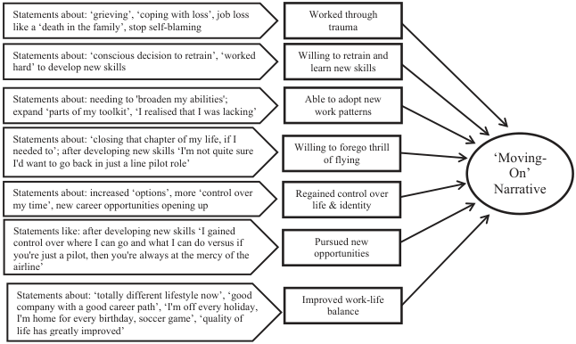

NOTE: figure/graphic rendered as an image from the PDF; its content is not machine-readable text. Caption (if any) follows as the next block.

**text found inside the figure**

Statements about: ‘grieving’, ‘coping with loss’, job loss like a ‘death in the family’, stop self-blaming

Statements about: ‘conscious decision to retrain’, ‘worked hard’ to develop new skills

Statements about: needing to 'broaden my abilities'; expand ‘parts of my toolkit’, ‘I realised that I was lacking’

Statements about: ‘closing that chapter of my life, if I needed to’; after developing new skills ‘I'm not quite sure I'd want to go back in just a line pilot role’

Statements about: increased ‘options’, more ‘control over my time’, new career opportunities opening up

Statements like: after developing new skills ‘I gained control over where I can go and what I can do versus if you're just a pilot, then you're always at the mercy of the airline’

Statements about: ‘totally different lifestyle now’, ‘good company with a good career path’, ‘I'm off every holiday, I'm home for every birthday, soccer game’, ‘quality of life has greatly improved’

‘Moving-

On’ Narrative

Worked through

trauma

Willing to retrain and

learn new skills

Able to adopt new

work patterns

Willing to forego thrill

of flying

Regained control over

life & identity

Pursued new opportunities

Improved work-life

balance

Statements about: inability to find a job, spouse supporting family, collecting donated food, driving taxi

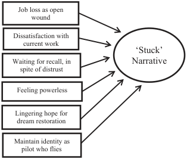

NOTE: figure/graphic rendered as an image from the PDF; its content is not machine-readable text. Caption (if any) follows as the next block.

**text found inside the figure**

Job loss as open

wound

Dissatisfaction with

current work

‘Stuck’ Narrative

Waiting for recall, in

spite of distrust

Maintain identity as

pilot who flies

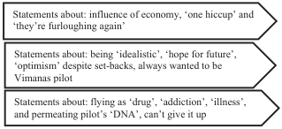

NOTE: figure/graphic rendered as an image from the PDF; its content is not machine-readable text. Caption (if any) follows as the next block.

**text found inside the figure**

Statements about: flying as ‘drug’, ‘addiction’, ‘illness’, and permeating pilot’s ‘DNA’, can’t give it up

Figure 1. Overview of data structure *All data derived from semi-structured interviews.

A. L. Fraher and Y. Gabriel 934

© 2014 John Wiley & Sons Ltd and Society for the Advancement of Management Studies

Page 10

chronological sequence’ (Creswell, 2003, p. 149). Inevitably this restorying goes, as Taylor (1971, p. 45f ) argues, beyond ‘brute data’, relying on empathetic readings and ‘unformallizable insights’, moments when a creative imagination is required in order to bridge the gaps between statements and theoretical categories, and between theoretical categories and aggregate explanations.

The fundamental divide between two core narratives (that we eventually termed ‘moving on’ and ‘stuck’) is what struck us first when ‘restorying’ our data. It was clear that some of our respondents had made the transition from actively flying planes to taking up other jobs (usually in sectors close to aviation) and settled in those jobs, regarding them as new and almost invariably better chapters in their working lives. A different story emerged from those pilots who were either completely without work or engaged in what they clearly saw as stop-gap jobs (selling cars or home improvements), waiting to be recalled to their pilot seats. We then noted the importance of flying planes for both groups – the first group viewed the move to non-flying jobs as a sacrifice they made, but one that eventually turned out to be a blessing in disguise. The second group also saw themselves as making a sacrifice – enduring the hardships and privations of being ‘on the street’ as the price they had to pay in order to return to the skies one day. Gradually, in our discussions, the critical importance of flying for the occupational identities of both groups became crystal clear, as did the two opposed outlooks of the two groups. It then struck us, that in spite of the big differences in the current predicaments of the two groups, their occupational bonds seemed unbroken, as was their bond to the first author who had left the profession and moved into academia. It seemed that what could account for the strength of this bond was a work experience unlike those of any other people, an experience based on flying big machines, fully in charge of the fates of many people travelling in them. This led to the idea of the occupational anchor as the focal point of occupational identity. The importance of this anchor was confirmed by the first author’s personal experience – one where a subsequent move to academia had by no means distanced her from the exhilaration and excitement of flying planes. It was then that, in our discussions, we realized that the love of flying was one that several of our respondents had mentioned as one dating to their childhood. We returned to our data, as we had done earlier, finding ample confirmation. At that point, we had a ‘Eureka moment’, linking the love of flying to some of humanity’s great flying archetypes, from Icarus and Phaëthon in antiquity to Batman and Superman in our times. We reflected on these archetypes, and Phaëthon, the hero obsessed with flying since childhood and whose flying career ends in a tragic fall, seemed to capture to perfection the plight of our respondents. Thus, the main findings that we shall outline presently (the shared narratives, the divergence, the ambiguities and certainties over their identities, the occupational anchor and, ultimately the ‘Phaëthon dream’) emerged not from a simple distillation of empirical material but through a constant probing and re-storying of narrative data, our comparisons with other occupational groups reported in the literature, our reflections and interrogations of plotlines and emotions present in the data, a constant testing of interpretations and conjectures, capped by moment of discovery that suddenly helped us make sense of our empirical material in what seemed an economical, meaningful, and powerful way.

Occupational Identity of Furloughed Airline Pilots 935

© 2014 John Wiley & Sons Ltd and Society for the Advancement of Management Studies

Page 11

#### **The Shared Narrative**

The relation between narrative and story has been extensively and inconclusively discussed by numerous authors (Buchanan and Dawson, 2007). Some are now opting for using the two terms interchangeably (Czarniawska, 2004; Polkinghorne, 1988) while others have drawn a line between the living story and the abstract narrative, only to move beyond both into the ‘fragmented, non-linear, incoherent, collective, unplotted, and pre-narrative’ space they refer to as antenarrative (Boje, 2001, p. 1). In the discussion that follows we shall maintain a distinction between a narrative and a story, whereby all stories are narratives but not all narratives are stories. In line with Gabriel’s (2000, p. 239) suggestion, we shall view stories as ‘narratives with plots and characters, generating emotion in narrator and audience, through a poetic elaboration of symbolic material. This material may be a product of fantasy or experience, including an experience of earlier narratives’.

In the course of our interviews we encountered numerous stories, relatively pithy narratives with beginnings, middles, and ends and relatively straightforward characters and plots. Cumulatively, a large number of stories whose meanings are overlapping or mutually reinforcing, further amplified by opinions and emotional expressions, can be said to amount to broader narratives of considerably greater complexity and ambiguity than single stories. Such narratives can be viewed as emerging from the contributions of several individuals, each providing clues not necessarily in the course of the same conversation, almost like the narratives recreated by barristers in a court of law on the basis of testimonies of different witnesses.

Drawn from a highly cohesive occupational community, having experienced very similar career successes and reversals, having worked for the same employer, the pilots in our sample supplied us with a very strong shared narrative, several features of which resurfaced in each interview. With the exception of point (4) below where there were some variations, the crucial features of this shared narrative can be presented as a set of ‘episodes’:

(1) A choice of career dictated by a dream of flying, frequently dating back to

childhood. (2) A belief that on being offered their first job by one of the major airlines, their

careers were on a derailment-proof path. (3) An acknowledgment that a pilot’s life involves numerous sacrifices of family and

social life, all made worthy by the financial and symbolic rewards of the career and the sheer exhilaration of flying planes. (4) An unsettling and anxiety-provoking experience of a first furlough following

9/11, forcing them to fall back on their savings and look for less well-paid jobs in and out of aviation [here there are some minor discrepancies in their personal narratives]. (5) A subsequent belief that, following recall, their careers had resumed on an

upward trajectory. (6) A deep rooted belief that the second furlough, unlike the first, was the result not

of economic exigencies but of bad management and corporate greed.

A. L. Fraher and Y. Gabriel 936

© 2014 John Wiley & Sons Ltd and Society for the Advancement of Management Studies

Page 12

(7) A highly personalized anger at the company’s CEO and senior management for

ruining the company, complemented by a slightly less venomous attitude at the union seen as complicit in the furloughs. (8) A deep resentment of older pilots who, by agreeing to prolong their service from

60 to 65 prior to retirement, consigned younger pilots, like those in the sample, to a second furlough. (9) An acceptance that conditions of work and salaries for pilots have been irrevo-

cably eroded as has the status of the piloting profession. (10) A belief that as the majors lose business to regional operators, salaries and

working conditions will erode further. (11) An acknowledgment that the furloughs and experiences in aviation have dis-

solved some of the dream that motivated their careers, replacing it with more ‘realistic’ or ‘cynical’ attitudes. (12) A view that the wider public is totally out of touch with the realities of the aviation

industry, and is not aware of how its thirst for cheap air tickets has irreparably damaged the industry and most especially the status and career of airline pilots.

While there were small variations among our respondents, these were minor and did not alter our impression that our respondents were flying from the same flight plan.

#### **THE DREAM OF FLYING**

The love of flying suffused most aspects of the interviews and was critically tied to the pilots’ choice of career, their occupational identity, and their responses to being furloughed. Clarke et al. (2012) described academics’ passionate love for their jobs but, if anything, the pilots’ love of flying is stronger, more akin to Maitlis’s (2009) account of the musical vocation that inspires professional musicians. For pilots, love of flying was addictive, even seen as an illness:

It’s an illness that we have to fly airplanes . . . It’s like cocaine to an addict . . . It’s that high you get . . . when I went to work. [Greg]

At the same time, a career in flying carried with it the promise of material and symbolic rewards. Similar to Faulkner’s (1973, pp. 340–41) symphony musicians’ ‘dream of having a first chair in one of the big orchestras’, the aviation dream for our pilots to captain at a major airline could only be realized through employment at one of only a few select air carriers. In this sense at least, they were firmly ‘organization men and women’ (Whyte, 1956).

For many pilots, like Christopher, Vimanas was explicitly part of their dream: ‘I was going to be a Vimanas pilot. It’s as simple as that. And I’ve had that dream probably for 30 years’. Anthony was even more specific in his aspirations: ‘My dream was to . . . Captain at Vimanas’ and when he was hired, he recalled, ‘that was just a magical moment for me. That was the pinnacle!’. The dream of a career in aviation and even being part of Vimanas was a fundamental part of the pilots’ occupational identity, an identity that incorporated a certain lifestyle with numerous privileges and sacrifices, all of which are part of a package:

Occupational Identity of Furloughed Airline Pilots 937

© 2014 John Wiley & Sons Ltd and Society for the Advancement of Management Studies

Page 13

I knew this was what I wanted to do from the time I was 5 years old . . . [It’s] probably inappropriately important to my identity! . . . Flying is not only my job but it’s also my favourite hobby which I think ties into why it’s probably way too much a part of my identity. It’s not only what I do for a living but it’s what I do for fun. [Karen]

Similar to paratroopers (Thornborrow and Brown, 2009), Vimanas pilots have a distinct sense of being part of a pilot elite, in sharp juxtaposition to those pilots who fly at the far less prestigious regional air carriers earning significantly less money, under poor employment conditions, and flying much smaller aircraft. And like Faulkner’s (1973) orchestra musicians, an additional aspect of pilots’ occupational identity is a shared concern that if one does not attain a certain position by a given age, prospective advancement is likely limited. It then becomes quickly apparent how painful it can be for a pilot who worked for the majors to find him- or herself out of work and demoted to flying for a regional airline. As one musician in Faulkner’s orchestra study reported, ‘Who wants to spend their life in the minor leagues?’ (p. 339).

It is clear then that for all of our pilots, flying and a career in aviation were aspects of an occupational identity built on a dream or ‘calling’ that acted as an occupational identity anchor similarly reported in other studies. Although these anchors provided people with the confidence and commitment they needed to succeed in their chosen field, there were complicated paradoxical implications as well. For instance, Bunderson and Thompson (2009) found by pursuing one’s calling there was an implication that workers should willingly make sacrifices in ways that left them vulnerable to exploitation. However, if they resisted exploitation and abandoned their calling, it would also be ‘a moral failure’; a neglect of one’s destiny and professional commitment (p. 41).

#### **Furloughs**

In the decade that followed 9/11, Vimanas declared bankruptcy and restructured, eliminating more than 5000 pilot jobs, or just over half its labour force. A pilot furlough is a lay-off from work with the right to return to flying, in seniority order, when and if the company needs them again. In this respect furloughs are less dramatic traumas than physical injury that threatens one’s career (Maitlis, 2009), or permanent dismissal (Gabriel et al., 2010) that brings an irreversible severance from one’s employer. Yet, waiting for recall consigns pilots to an employment limbo land from which he or she may never fully recover in terms of their seniority on a preferred aircraft at a major airline. Furloughs have long been a feature of a career in aviation, and therefore have been an element of occupational identity accepted without stigmatization or shame. Those of our pilots with fathers or relatives in aviation were aware of the stories told about the wave of furloughing that followed the oil crisis of the 1970s. These pilots were better prepared to weather the storm with the help of savings, especially if they did not have extensive family and financial commitments. Nonetheless, following the traumatic events of 9/11 in 2001, especially for those working in the aviation industry, most pilots experienced the first furlough as a distressing event, filling them with fear and anxiety for the future:

I knew it was happening but that phone call felt like the guillotine blade was coming down . . . There were others relying on me and so I pictured the worst: bankruptcy,

A. L. Fraher and Y. Gabriel 938

© 2014 John Wiley & Sons Ltd and Society for the Advancement of Management Studies

Page 14

losing a home, losing my family . . . All the worst scenarios went around in my head and luckily none of them happened. I was very scared. [Aaron]

As months without work turned to years, several of our respondents resorted to other forms of employment. Some found less well-paid jobs in aviation, taking over a 60 per cent pay cut. Others tried different jobs such as selling cars, driving taxis, or projectmanaging for construction companies. Many applied feverishly, yet unsuccessfully, for jobs for which they were not qualified, lapsing into disappointment and depression. Some moved back in with their parents. All made use of their savings to see them through the hardship, but several reported severe financial strains including resorting to charity food banks to support their families.

In spite of these slight variations, when the pilots interviewed here were finally recalled in 2006–07, they all responded by abandoning whatever they were doing, including well-paid flying jobs at other air carriers, to return to their dream at Vimanas. They believed that they had survived the crisis, the worst was behind them, and their careers were about to resume an upward trajectory, towards the dream of captaining a widebody jet. This rekindling of hopes, however, did not last long. Two years later, the company announced its intention to downsize its fleet ostensibly in response to the 2008 financial crisis, ensuing economic recession, and rising fuel costs. As a result, 1437 pilots were furloughed a second time, a number that included our respondents and was of great symbolic significance to them.

If the first furlough was seen as the outcome of 9/11, pilots were unanimous in seeing the second furlough as the deliberate result of management’s strategy to outsource and off-shore a substantial part of its business ahead of a merger, driven by naked bottom line considerations. Thus, the second furlough aroused much greater anger among our respondents, an anger that was invariably personalized and targeted at Vimanas senior management, as Aaron described:

The second time I was more angry; less scared, and more angry because I knew the real reason I was being furloughed . . . The merger, it was a pure business decision and I feel down deep that the reason it was done is because that way [the CEO] can collect his money after the companies have merged and everyone else be damned.

As an occupational identity group, the pilots interviewed displayed a remarkable degree of bitterness, disenchantment, and loss of trust in their airline (Fraher, 2013). The second furlough had brought about a cynicism and a distancing from their earlier career dreams; occupational identity anchors that were now often described as naïve or childish (Costas and Fleming, 2009).

[My career dream] it’s almost, it’s laughable, I mean . . . ever since [the 1980s], it’s been a steady decline of the quality of the job, whether it’s pay and benefits, whether it’s work rules, schedules, respect from either the public or certainly the company or even your working peers or working co-workers. [Doug]

Our personal identity’s so tied up in what we do that when you do become unemployed it is coping with loss. It’s certainly not on the scale of a death in the family, but

Occupational Identity of Furloughed Airline Pilots 939

© 2014 John Wiley & Sons Ltd and Society for the Advancement of Management Studies

Page 15

it is a significant loss. And you go through the same grieving processes and coping processes and conceptualizing the issues that people who do experience a loss have to cope with. [Raj]

As Doug and Raj relate, many pilots seemed more upset over the loss of their dream than the loss of their airline job. The second furlough, like the first, was a collective calamity. Unlike other of life’s traumas, such as personal injury, illness, or individual dismissal, it affected a whole class of professionals who found themselves once again en masse in limbo land. Similar to the first furlough, the second represented a challenge to pilots’ occupational identity, that is, the discursive and rhetorical resources necessary to sustain their view of themselves as members of an elite and distinct group. Yet, the pilots’ response to the second challenge manifested itself in two distinctly different ways.

#### **THE NARRATIVES DIVIDE**

Although all our respondents remained committed to their occupational identity as pilots, their organizational identity and airline loyalty seemed to be in steady decline. Some pilots ‘moved on’, getting work in other companies and re-starting their lives and careers outside Vimanas or the aviation industry altogether. The remainder found themselves ‘stuck’ in what they view as poorly paid, stop-gap, temporary jobs or without any work, drawing on unemployment, savings, and spouses’ earnings, just waiting to be recalled to a company they no longer respect or trust (Fraher, 2013). The emotional and identity constructions of the two are quite different. This split between individuals who, following job loss, move on to start new careers and those who remain stuck, hoping to rekindle their earlier career, is not uncommon. It has been noted among several professional groups (Eby and Buch, 1994; Fineman, 1983; Mendenhall et al., 2008) as well as members of manual occupations (Creed and Moore, 2006; Ezzy, 2001). What is significant in our findings is, first, the unwavering commitment of all respondents, even those no longer flying planes, to an idea of themselves as pilots. And second, the enduring embrace of the Phaëthon dream, their occupational fantasy, both as a justification for past and present choices and as a way of way of sustaining individual selfhoods through difficult times.

#### **The ‘Moving On’ Narrative**

Five of the ten pilots had clearly ‘moved on’. Three had taken jobs in industries related to aviation but were no longer flying airliners. One was flying an executive jet part time and one had moved to a different major airline, starting over at the bottom of the seniority list once again. These pilots had acquired new skills and made a clean break from their earlier careers in Vimanas. The main features of the ‘moving on’ narrative were:

(1) An acknowledgment of having lived through the trauma of losing their dream and

worked through resultant feelings of victimization, anger, and betrayal. (2) A willingness to retrain, adapt, and learn new skills. (3) A readiness to be flexible and adopt new patterns of work. (4) A willingness to forego the thrills of flying airplanes and find new occupational

identity anchors, if required.

A. L. Fraher and Y. Gabriel 940

© 2014 John Wiley & Sons Ltd and Society for the Advancement of Management Studies

Page 16

(5) A sense of regaining control over their lives and their occupational identity. (6) An opening up of opportunities and choices. (7) An overall improvement in their work–life balance.

The fundamental quality highlighted by the moving on narrative is flexibility, the individual’s ability to learn new skills, both technical and psychological, and reinvent themselves in new careers. Raj explained how his personal metamorphosis allowed him to ‘move on’:

Pilots are really good at flying airplanes but if there’s no airplanes to fly, unless you’ve developed other abilities, you’re somewhat stuck. So it was sort of a conscious decision on my part [to retrain] . . . When I looked at myself, I realized that I was lacking in some [areas] . . . and I worked hard at developing that element of my game. [Raj]

Flying remained part of the identity narrative of these professionals; they still enjoyed flying and even entertained the possibility of returning to an active piloting career someday. But, as Aaron explained, it became a less defining aspect of their occupational identity:

Flying was more important for my self-identity than my current career is now . . . It consumes you, it’s your life and you identify with it very, very highly. With my current job, I like my job, I work for a big company, I work with a bunch of good people. But I don’t identify myself with my job now as much as I did with flying. [Aaron]

Developing new skills opened up options for these ‘moving on’ pilots; they felt that they had choices and were in control of their lives, as Graham described:

Right now, I have a lot of control over my time . . . I have options. I could go to China [to fly] if I wanted to . . . This other opportunity opened up to me to fly this [corporate jet] and because of my past experience it’s been a real easy transition . . . I think it’s well in control. [Graham]

‘Moving on’ from a career at Vimanas, these pilots found that their quality of life had substantially improved. Most found they were able to spend more time with their families, plan their holidays, and have much greater control over their day-to-day activities. Pilots who had moved on from aviation did not deny the pain and loss they had endured in relinquishing their pilot seats, but these were no longer ‘open wounds’. They had opened a new chapter in their lives, while acknowledging that this had involved a sacrifice of something deeply valuable to them.

#### **The ‘Stuck’ Narrative**

The opposite was the case in the ‘stuck’ narrative – the five pilots in this category were highly dissatisfied with their situation. The main features of their narrative were:

(1) An experience of losing their job as an open wound, accompanied by sustained

bitterness, anger, and feelings of victimization. (2) Extensive dissatisfaction with current work situation. (3) Waiting to be recalled, in spite of distrusting and even despising their airline. (4) Extensive feelings of powerlessness. (5) A lingering hope that their dream of aviation, as an occupational identity anchor,

could be restored. (6) A determination to maintain their occupational identity as pilots who fly airplanes

at all costs.

In the first place, all of the ‘stuck’ pilots were dissatisfied with their current jobs. They were all working in part-time or temporary jobs which paid significantly less than what they would have earned flying for Vimanas. Tom was flying part-time in a poorly-paid job that necessitated drawing heavily on his wife’s earnings and their joint savings. Like pilots in the ‘moving on’ narrative, Tom had retrained but had had ‘no nibbles’. Although he was one of the most vocal about the ‘greed’ and ‘selfishness’ of airline leaders, when asked if he would return to Vimanas if recalled he was unequivocal: ‘Yes, I mean . . . it’s still a really good job and you wouldn’t find much better [pay] for the work you have to put in. So, yes, I would for sure’.

Similarly Anthony, who remained unemployed, said simply: ‘Yes I will go back because I don’t have anything else going’. And Doug, currently working for a small charter airline, said:

It becomes a choice between Charter flying making $25,000 a year or going back to Vimanas. Now it’s not all about the cash, however $25,000 a year for the rest of my career just will not cut it. So Vimanas is really the next option . . . I’ll probably go back.

Thus, a fundamental factor distinguishing those in the ‘stuck’ narrative was their attitude about waiting to be recalled. Another key difference between the two narratives concerned the issue of control. When asked how much control they exercised over their work or their lives, ‘stuck’ pilots’ answers were typically negative:

Oh zero, I mean, if I want to stay in this industry. Pretty much zero. [Tom]

Zero . . . It’s something I basically can’t really control. . . . All it takes is one hiccup in the economy and they’re furloughing again and then you’re back into the same pattern. [Greg]

Er, [chuckles] Control over my career? Very, very little . . . I’m basically an hourly worker. [Anthony]

Lack of control and a passive waiting attitude define the subject positions adopted by ‘stuck’ pilots. These are not exactly victim identities but they are deeply entrapped identities; occupational identities that conceive of the future as a return to the past. It is this hope that sustains them. What is remarkable about these ‘stuck’ narratives is the extent to which their authors are prepared to cling to the dream.

I still am idealistic about the fact that I really do think it’s a dream job and you know, I just – I think that . . . I used to have a very, very charmed life . . . My life was – you know, much, much, much simpler, much less complicated than it is now. But the furlough is just an element of that, that’s all. [Christopher]

Doug, another ‘stuck’ pilot, gave a very insightful account of how, at a conscious level, he does seek to detach his identity from flying and from Vimanas. Yet somehow, something in him maintains the occupational identity connection in spite of deteriorating conditions:

[Being a pilot] is not how I define my life. I have too many other things going on and too many other people in my life that are more important than aviation. And yet, I had two opportunities to completely shift gears professionally and found myself coming back twice . . . Even with all the knocks . . . [the need to fly] sort of permeates the DNA of some people . . . It permeates my DNA too. [Doug]

Like Doug maintaining an occupational identity, anchored in the dream to fly jets at a major airline, is something that all five of the ‘stuck’ pilots described as difficult and painful, and something they tried unsuccessfully to move beyond.

Unfortunately I probably attributed more [to my aviation career identity] than I should have done, which probably led to all the anger. I’m starting to let go of some of that . . . in order to keep myself sane . . . I mean not – not let go of the dreams or the identity of myself [as a major airline pilot] but . . . not keep myself wrapped up in [thinking] ‘Oh what could have been’ and ‘should have been’. [Tom]

The ‘stuck’ narrative demonstrates strongly how difficult it is for professionals to abandon an occupational identity anchor like the dream of flight and idealization of captaining at a major airline. Even those who have ‘moved on’ are unwilling to completely abandon the dream, but for those who find themselves ‘stuck’ in derailed pilot careers, the dream becomes even more valuable as a signifier of occupational identity. The dream and the sense that they were once close to realizing it is what sustains them through their present hardships.

#### **DISCUSSION**

Like other professional groups, such as orchestral musicians (Faulkner, 1973), elite military groups (Thornborrow and Brown, 2009), academics (Clarke et al., 2012), and zookeepers (Bunderson and Thompson, 2009), pilots view their work as a ‘calling’. The dream of flight and the pleasure of flying are parts of an occupational identity sustained by a love for the work they do. What sets pilots apart from other professional groups is, first, that that their identities are not insecure or fragile in the way Clarke et al. (2012) described those of academics. These pilots also do not seem to lapse into ‘might have beens’, unrealized possibilities in their lives, and regrets about opportunities missed (Obodaru, 2012). Far from it – they are among those people who view

themselves as lucky to have discovered their true vocation and to have realized their calling. Exactly as noted by Ashcraft (2005, 2007), these professionals have no doubts that they are highly competent in flying planes and that they have what it takes to rise to the top of their profession. Although two pilots expressed some anxiety about losing their medical certification and having to forfeit their pilot license, for both ‘stuck’ and ‘moving on’ pilots their occupational identity seemed very robust. We find this, in part, a result of the occupational identity anchors that underpinned their career aspirations, motivating them to do whatever it took to become a Vimanas pilot in the first place.

However, what varied in the pilots’ narratives is how these identity anchors shaped their experiences and behaviours after furlough. ‘Stuck’ pilots were weighed down by their occupational identity anchors, being held back from other career options. Although they were angry, bitter, and highly dissatisfied with their current work situation, they were determined to maintain their occupational identity as pilots who fly planes at all costs. In spite of distrusting and even despising their airline’s leaders, they were nonetheless fixated on being recalled to work as the only solution to their plight. In this regard, they were entrapped in a particular occupational identity linked to their calling which they were unable to relinquish. This then was a lived paradox for these pilots: their occupational identities both sustained them and hindered them.

In contrast, for ‘moving on’ pilots, occupational identity anchors provided the stability and confidence they needed to start another career. These pilots reported the same sense of trauma about losing their dream as did ‘stuck’ pilots, but they had worked through resultant feelings of victimization, anger, and betrayal. Although they all still held firm occupational identities as pilots, there was a willingness to forego the thrills of flying airplanes as a way to regain control over their lives. They demonstrated flexibility and a willingness to retrain, adapt, learn new skills, and adopt new patterns of work which ‘stuck’ pilots resisted. Their occupational identity still exercised a considerable influence on their outlooks and experiences but, instead of entrapping them, offered them the self-confidence and strength to search for new work opportunities.

Unlike other professionals (Gabriel et al., 2010; Letkemann, 2002), neither pilot group viewed being furloughed as a process of stigmatization. Similar to Newman’s (1988) study of striking air traffic controllers, pilots viewed furlough as an aspect of their occupational identity and a necessary risk involved in pursuing their calling. Yet, they were clear in their distinction between feelings about their occupational identity as a major airline pilot and their organizational identity as a Vimanas employee. All pilots, but especially those in the ‘stuck’ narrative, felt betrayed by the company they had once idealized. Even then, blaming the CEO and top managers seemed like an attempt to absolve the company and to preserve something ‘good’ about the airline that had helped co-create their occupational identity. The company as an organizational ideal (Gabriel, 1993; Hirschhorn and Gilmore, 1989; Schwartz, 1987) was thus kept apart from the actions of its greedy, selfish, and disingenuous executives. The result was a partial dis-identification of the pilots from the company and a lingering hope, at least among some, that a new managerial regime and an improved climate for aviation would restore their careers and company to their earlier glory days. It is as if, unconsciously, the company was split between a good and shining organization as it had been in the past,

and a cruel and deceitful organization as it had turned into by its current senior management (Fotaki and Boyd, 2005; Hirschhorn, 1988).

This partial dis-identification was, unsurprisingly, accompanied by the familiar phenomena of cynicism and distancing (Fleming and Spicer, 2003). The pilots’ early dream of flight was seen as naïve and idealistic, yet one that was far from extinguished. Those in the ‘stuck’ narrative held on to a hope that, somehow, at least part of their career might be salvaged. Similarly, all but one of the five pilots who had ‘moved on’ felt that the dream remained an important part of their present identity, even if its realization now seemed unlikely. This was evident in responses to the question ‘How much of your earlier self, the one who started in aviation, do you recognize in yourself today?’ And this seems to us to be a unique feature of these professionals that sets them apart from certain other groups who have been the subject of identity scholarship. This is what we call the ‘Phaëthon dream’.

Phaëthon was a young man in Greek mythology, obsessed with flying the chariot of his father Helios, the sun god. One day he secretly yoked his father’s horses and set out to fly the chariot in the sky. Unable to control the horses, he crashed to earth burning everything along the way and, in at least some versions of the story, turning much of North Africa into a desert. Unlike Icarus, the other flying hero who became inebriated while flying to escape captivity, Phaëthon had longed to fly since his early days and it is this that makes him an appropriate archetype for a childhood desire to fly. This is very prominent among pilots, but arguably expresses a deeper human fantasy to fly and, maybe by extension, to be free from the earthly constraints of gravity, toil, and neediness. This is the likely explanation of why there seems to be no greater insult to the pilots we interviewed than to liken them to bus drivers, something that denies the elemental quality of the dream that inspired them. Even when, Phaëthon-like, the dream sends their careers and livelihoods crashing, many of them find it hard to let go. This also explains why they appeared angrier and more cynical over the loss of their dream rather than the loss of their job itself. And finally, this may be what prompted their very charged and ambivalent responses to the question ‘What advice would you give to a person who is dreaming to become a pilot?’ that ranged from ‘You don’t have the right to destroy a person’s dream’ to ‘I would never let my children become pilots’.

The Phaëthon dream can be viewed as an occupational fantasy, a shared, idealized, and highly charged construction, acting as an identity anchor. It provides a firm, invariant point which gives meaning to everything else, a primal desire and a fantasy in the name of which pilots are willing to make many sacrifices and submit to many disciplines, but one that sustains them and supports them throughout their lives. It is the key to understanding their life stories, their deep-seated hesitation to move on, their sense of betrayal, their anger, but also their strong belief in themselves. It can be argued that the same key opens the door to identity construction of other occupational groups that view themselves as following their vocation. It is noteworthy that members of such groups are known for being able to endure disappointments and privations without fundamentally derailing their occupational identity; thus a musician or a former paratrooper may still draw his/her identity by identifying with their profession, long after their last successful gig or their last professional achievement.

The Phaëthon motif opens another important insight into the identity construction process of these pilots reflecting their assumption that, once on board the Vimanas shining chariot, their careers were guaranteed an upward trajectory. According to this assumption, which surfaced repeatedly in the interviews, Vimanas was experienced as the vehicle to an unstoppable rise to the top, Mount Olympus itself. This part of the dream came crashing with successive furloughs and forced grounding – their corporate fall mirroring exactly Phaëthon’s crash to the ground (van den Hooff, 2012; Winstanley, 2004).<sup>[1]</sup> For pilots who remained in the ‘stuck’ position, when contrasted with their current reduced circumstances, memories of former glories became both unbearable and inseverable – unbearable, because the realization of the dream had seemed so close, and yet, inseverable, because without them, their predicament would be hardly different from that of unemployed bus drivers. It became impossible to let go of the Phaëthon moment – when the pinnacle had seemed within their grasp.

Linking the occupational fantasy of flying to an ancient myth highlights its unconscious and timeless qualities. Myths are not ordinary narratives or stories; they carry powerful symbolism, they are capable of generating strong emotions, and they have a profound effect on actions and thoughts. They persist and are shared across time and space, assuming many different but interlinked forms. A myth embodies larger than life meanings, revolving around unique deeds performed by supernatural heroes and addressing the enduring mysteries of life, that as Barthes (1973) suggested, lose their historical bearings. Mythical characters and motifs recur across time and space, retaining their ability to move, to arouse, and to engage. Many social scientists (e.g., Armstrong, 2005; Douglas, 1975; Lévi-Strauss, 1978) view human beings as myth-creating animals, animals who do not merely create myths, but need to inhabit a universe whose myths express some of the profound contradictions, anxieties, and desires of the human condition. Thus Jung (1968) saw myths as the conscious carriers of archetypes residing deep in a collective unconscious. These are elements of the great stream of ideas and images that flows through the soul of every human being, surfacing from time to time in dreams, images, fantasies, stories, ecstatic and other experiences. Locating the pilots’ Phaëthon dream in a myth may account for the enduring, shared, and communal qualities of the former. As Campbell has argued, ‘dream is the personalized myth, myth the depersonalized dream; both myth and dream are symbolic in the same general way of the dynamics of the psyche. But in the dream, the forms are quirked by the peculiar troubles of the dreamer, whereas in myth the problems and solutions shown are directly valid for all mankind’ (Campbell, 1949/1988, p. 19).

The mythological qualities of organizational and occupational narratives have not attracted as much attention as other aspects, but there has been a steady growth of scholarship and interest in them (e.g., Bowles, 1989; Gabriel, 2004b; Kostera, 2008a, 2008b, 2008c; Moxnes, 1999). These works suggest that contemporary organizational and professional life may displace some of the traditional functions of myth with scientific and other substitutes; yet, enduring mythical archetypes and plotlines can be found regularly in organizational and occupational narratives, displaying unconscious fantasies and desires similar to those of more traditional myths. In this light, the mythical archetype of Phaëthon can be viewed as the protagonist in the core occupational narratives of pilots and one which provides a shared focus of identification and inspiration.

#### **CONCLUSION**

Shared occupational fantasies may be features of other occupational groups too. Based on our experience with airline pilots, we suggest that occupational fantasies draw members of a profession together, and provide a basis for solidarity and intimacy, acting as anchors that stabilize and fix their occupational identity. The metaphor of an anchor captures very well the dual quality of an occupational fantasy. An anchor stabilizes vessel movement, fixing it in place in order to stop drift in calm seas and stabilize rock in rough seas. And an anchor also prevents a vessel from moving on when weather and other conditions may dictate that moving is a sensible and rational option. The anchor’s firmness also captures well the quality of a vocation, at least as envisaged by Weber et al. (2004), as a career choice driven by a quest for intrinsic and permanent value rather than ephemeral instrumental considerations. Finally, anchor symbolism reflects our informants’ fixation on the thing that, above all, made them unique: flying planes.

Like other fantasies, occupational fantasies are generally not liable to correction by appeal to instrumental reason, since they express deeply held and usually unconscious desires. Future inquiry may identify similar deeply held desires and corresponding fantasies in other occupational groups that are drawn to their work by a calling. Such work may even be able to link the occupational fantasies of certain groups to specific mythological archetypes as we have done here. Musicians, for instance, could be seen as inspired by the Orpheus dream, dancers by the Bacchus dream and so forth. A single study, of course, is not adequate in establishing such links. Inevitably different professional groups have their own particularities, but an argument may begin to emerge that many of the established professions (clergy, medicine, law, science, teaching) are inspired by some collective mythical archetype which supports idealized images of the profession and animates the identities of its members. It could well be that such archetypes fuel some of the resistances to attempts to submit professional authority to market disciplines.

What this paper has contributed is a demonstration of the power of an archetype originating in early childhood on the occupational identities of one particular group, airline pilots. In particular, we have shown how the Phaëthon dream inspired the pilots in their choice of work, motivated them through the early phases of their career, shaped their expectations, moulded their relation and identification with their employer, and sustained them through the hardships of successive furloughs. In all these ways, the dream was a shared occupational fantasy that anchored the pilots’ occupational identity. This same dream was experienced as holding some of them back and preventing them from moving on, when the chances of its fulfilment had vanished. Even then, however, it stabilized and comforted them, when all else seemed lost and they awaited recall.

Our paper has also offered some insights into how the structural changes sweeping through the aviation industry, including mergers, downsizing, and outsourcing, are affecting members of a once powerful and privileged profession that is currently undergoing extensive downgrading. The dilemmas and paradoxes experienced by pilots in our study may offer advance notice to members of other professions, whose assumptions and fantasies are liable to be tested by emerging market demands. Maintaining such assumptions and fantasies may become increasingly costly and painful for them, just as it became

so for some of the pilots in our study, trapping them in occupational identities incommensurable with their working circumstances. Yet, our paper has also offered some hope regarding the ability of at least some members of a profession who, having experienced the trauma of unemployment, are able to revive their lives and their careers through a mixture of resilience, flexibility, and luck, without denying or betraying the dreams that had once taken hold of them.

#### **NOTE**

[1] These are two earlier explorations of the Phaethon motif in relation to careers, neither of which deals

with the careers of individuals actually flying planes. Winstanley (2004) uses the motif to explore the difficulties of people who were overshadowed by a brilliant (but uncaring) parent, and van den Hoof (2012) addresses the career collapses of ‘high flying’ bankers, once deemed to have been of exceptional brilliance.

#### **REFERENCES**

Ainsworth, S. and Hardy, C. (2009). ‘Mind over body: physical and psychotherapeutic discourses and the

regulation of the older worker’. *Human Relations*, **62**, 1199–229. Alvesson, M. (2001). ‘Knowledge work: ambiguity, image and identity’. *Human Relations*, **54**, 863–86. Alvesson, M. (2010). ‘Self-doubters, strugglers, storytellers, surfers and others: images of self-identities in

organization studies’. *Human Relations*, **63**, 193–217. Alvesson, M. and Kärreman, D. (2007). ‘Constructing mystery: empirical matters in theory development’.

*Academy of Management Review*, **32**, 1265–81. Alvesson, M. and Robertson, M. (2006). ‘The best and the brightest: the construction, significance and

effects of elite identities in consulting firms’. *Organization*, **13**, 195–224. Alvesson, M. and Sköldberg, K. (2009). *Reflexive Methodology: New Vistas for Qualitative Research*. London: Sage. Alvesson, M., Ashcraft, K. L. and Thomas, R. (2008). ‘Identity matters: reflections on the construction of

identity scholarship in organization studies’. *Organization*, **15**, 5–28. Armstrong, K. (2005). *A Short History of Myth*. Edinburgh: Canongate. Ashcraft, K. L. (2005). ‘Resistance through consent? Occupational identity, organizational form, and the

maintenance of masculinity among commercial airline pilots’. *Management Communication Quarterly*, **19**, 67–90. Ashcraft, K. L. (2007). ‘Appreciating the “work” of discourse: occupational identity and difference as

organizing mechanisms in the case of commercial airline pilots’. *Discourse & Communication*, **1**, 9–36. Barthes, R. (1973). *Mythologies*. London: Paladin Books. Boje, D. M. (2001). *Narrative Methods for Organizational and Communication Research*. London: Sage. Bowles, M. L. (1989). ‘Myth, meaning and work organization’. *Organization Studies*, **10**, 405–21. Brown, A. (2006). ‘A narrative approach to collective identifies’. *Journal of Management Studies*, **43**, 731–53. Brown, A. D. and Humphreys, M. (2002). ‘Nostalgia and narrativization of identity: a Turkish case study’.

*British Journal of Management*, **13**, 141–59. Bruner, J. S. (1995). ‘The autobiographical process’. *Current Sociology*, **43**, 161–77. Buchanan, D. and Dawson, P. (2007). ‘Discourse and audience: organizational change as a multi-story

process’. *Journal of Management Studies*, **44**, 669–86. Bunderson, J. S. and Thompson, J. A. (2009). ‘The call of the wild: zookeepers, callings, and the double-

edged sword of deeply meaningful work’. *Administrative Science Quarterly*, **54**, 32–57. Calhoun, L. G. and Tedeschi, R. G. (2004). ‘The foundations of posttraumatic growth: new considerations’.

*Psychological Inquiry*, **15**, 93–102. Cameron, D. (2001). ‘Chefs and occupational culture in a hotel chain: a grid-group analysis’. *Tourism and*

*Hospitality Research*, **3**, 103–14. Campbell, J. (1949/1988). *The Hero with a Thousand Faces*. London: Paladin Books. Clarke, C., Brown, A. D. and Hailey, V. H. (2009). ‘Working identities? Antagonistic discursive resources

and managerial identity’. *Human Relations*, **62**, 323–52. Clarke, C., Knights, D. and Jarvis, C. (2012). ‘A labour of love? Academics in business schools’. *Scandinavian*

*Journal of Management*, **28**, 5–15.

Cornelissen, J. P. (2002). ‘On the “organizational identity” metaphor’. *British Journal of Management*, **13**,

259–68. Costas, J. and Fleming, P. (2009). ‘Beyond dis-identification: a discursive approach to self-alienation in

contemporary organizations’. *Human Relations*, **62**, 353–78. Coupland, C. and Brown, A. D. (2012). ‘Identities in action: processes and outcomes’. *Scandinavian Journal of*

*Management*, **28**, 1–4. Creed, P. A. and Moore, K. (2006). ‘Social support, social undermining, and coping in underemployed and

unemployed persons’. *Journal of Applied Social Psychology*, **36**, 321–39. Creswell, J. W. (2003). *Research Design: Qualitative, Quantitative, and Mixed Approaches*. London: Sage. Creswell, J. W. and Maietta, R. C. (2002). ‘Qualitative research’. In Miller, D. C. and Salkind, N. (Eds),

*Handbook of Research Design and Social Measurements*, 6th edition. Thousand Oaks, CA: Sage, 143–84. Cunliffe, A. L. (2003). ‘Reflexive inquiry in organizational research: questions and possibilities’. *Human*

*Relations*, **56**, 983–1003. Czarniawska, B. (2004). *Narratives in Social Science Research*. London: Sage. Das, D. (2012). ‘Effects of identity variables and job performance on employee intentions to leave: an

empirical study in Indian call centers’. *International Journal of Management*, **29**, 368–78. Davis, C. G., Nolen-Hoeksema, S. and Larson, J. (1998). ‘Making sense of loss and benefiting from the

experience: two construals of meaning’. *Journal of Personality and Social Psychology*, **75**, 561–74. Douglas, M. (1975). ‘The meaning of myth’. In Douglas, M. (Ed.), *Implicit Meanings: Essays in Anthropology*.

London: Routledge, 153–73. Eby, L. T. and Buch, K. (1994). ‘The effect of job search method, sex, activity level, and emotional

acceptance on new job characteristics – implications for counseling unemployed professionals’. *Journal of Employment Counseling*, **31**, 69–82. Ezzy, D. (2001). *Narrating Unemployment*. Burlington, VT: Ashgate. Faulkner, R. R. (1973). ‘Career concerns and mobility motivations of orchestra musicians’. *Sociological*

*Quarterly*, **14**, 334–49. Fine, G. A. (1996). ‘Justifying work: occupational rhetorics as a resource in restaurant kitchens’. *Administrative*

*Science Quarterly*, **41**, 90–115. Fineman, S. (1979). ‘A psychosocial model of stress and its application to managerial unemployment’. *Human*

*Relations*, **32**, 323–45. Fineman, S. (1983). *White Collar Unemployment: Impact and Stress*. Chichester: Wiley. Fleming, P. and Spicer, A. (2003). ‘Working at a cynical distance: implications for power, subjectivity and

resistance’. *Organization*, **10**, 157–79. Fotaki, M. and Boyd, A. (2005). ‘From plan to market: a comparison of health and old age care policies in

the UK and Sweden’. *Public Money & Management*, **25**, 237–43. Fraher, A. L. (2004). ‘Flying the friendly skies: why U.S. commercial airline pilots want to carry guns’. *Human*

*Relations*, **57**, 573–95. Fraher, A. L. (2012). ‘When profit-seeking trumps safety: the risks and opportunities of liminality in

commercial aviation in post-9/11 America’. In Long, S. and Seivers, B. (Eds), *Towards a Socioanalysis of Money, Finance and Capitalism*. New York: Routledge, 192–206. Fraher, A. L. (2013). ‘Airline downsizing and its impact on team performance’. *Team Performance Management*,

**19**, 109–26. Franke, M. and John, F. (2011). ‘What comes next after recession? Airline industry scenarios and potential

end games’. *Journal of Air Transport Management*, **17**, 19–26. Gabriel, Y. (1993). ‘Organizational nostalgia: reflections on the golden age’. In Fineman, S. (Ed.), *Emotion in*

*Organizations*. London: Sage, 118–41. Gabriel, Y. (2000). *Storytelling in Organizations: Facts, Fictions, Fantasies*. Oxford: Oxford University Press. Gabriel, Y. (2004a). ‘The glass cage: flexible work, fragmented consumption, fragile selves’. In Alexander,

J. C., Marx, G. T. and Williams, C. L. (Eds), *Self, Social Structure and Beliefs*. Berkeley, CA: University of California Press, 57–76. Gabriel, Y. (Ed.) (2004b). *Myths, Stories and Organizations: Premodern Narratives for Our Times*. Oxford: Oxford

University Press. Gabriel, Y. (2005). ‘Glass cages and glass palaces: images of organizations in image-conscious times’.

*Organization*, **12**, 9–27. Gabriel, Y., Gray, D. E. and Goregaokar, H. (2010). ‘Temporary derailment or the end of the line?

Managers coping with unemployment at 50’. *Organization Studies*, **31**, 1687–712. Giddens, A. (1991). *Modernity and Self-Identity: Self and Society in the Late Modern Age*. Stanford, CA: Stanford

University Press.

Gittell, J. H., Von Nordenflycht, A. and Kochan, T. A. (2004). ‘Mutual gains or zero sum? Labor

relations and firm performance in the airline industry’. *Industrial & Labor Relations Review*, **57**, 163–80. He, H. W. and Baruch, Y. (2010). ‘Organizational identity and legitimacy under major environmental

changes: tales of two UK building societies’. *British Journal of Management*, **21**, 44–62. Hirschhorn, L. (1988). *The Workplace Within*. Cambridge, MA: MIT Press. Hirschhorn, L. and Gilmore, T. N. (1989). ‘The psychodynamics of a cultural change: learning from a

factory’. *Human Resource Management*, **28**, 211–33. Hopkins, G. E. (1971). *The Airline Pilots: A Study in Elite Unionization*. Cambridge, MA: Harvard University

Press. Humphreys, M. and Brown, A. (2002). ‘Dress and identity: a Turkish case study’. *Journal of Management*

*Studies*, **39**, 927–52. Ibarra, H. (1999). ‘Provisional selves: experimenting with image and identity in professional adaptation’.

*Administrative Science Quarterly*, **44**, 764–91. Ibarra, H. and Barbulescu, R. (2010). ‘Identity as narrative: prevalence, effectiveness, and consequences of

narrative identity work in macro work role transitions’. *Academy of Management Review*, **35**, 135–54. Jahoda, M. (1982). *Employment and Unemployment*. Cambridge: Cambridge University Press. Johnson, M. D., Morgeson, F. P., Ilgen, D. R., Meyer, C. J. and Lloyd, J. W. (2006). ‘Multiple professional

identities: examining differences in identification across work-related targets’. *Journal of Applied Psychology*, **91**, 498–506. Jung, C. G. (1968). *The Archetypes and the Collective Unconscious*. London: Routledge. Kitay, J. and Wright, C. (2007). ‘From prophets to profits: the occupational rhetoric of management

consultants’. *Human Relations*, **60**, 1613–40. Kostera, M. (2008a). *Mythical Inspirations for Organizational Realities*. New York: Palgrave Macmillan. Kostera, M. (2008b). *Organizational Epics and Sagas: Tales of Organizations*. New York: Palgrave Macmillan. Kostera, M. (2008c). *Organizational Olympians: Heroes and Heroines of Organizational Myths*. New York: Palgrave

Macmillan. Leana, C. R. and Ivancevich, J. M. (1987). ‘Involuntary job loss: institutional interventions and a research

agenda’. *Academy of Management Review*, **12**, 301–12. Letkemann, P. (2002). ‘Unemployed professionals, stigma management and derivative stigmata’. *Work*

*Employment and Society*, **16**, 511–22. Lévi-Strauss, C. (1978). *Myth and Meaning: The 1977 Massey Lectures*. London: Routledge. Lewis, P. (2008). ‘Emotion work and emotion space: using a spatial perspective to explore the challenging of

masculine emotion management practices’. *British Journal of Management*, **19**, 130–40. Lippmann, S. (2008). ‘Rethinking risk in the new economy: age and cohort effects on unemployment and

re-employment’. *Human Relations*, **61**, 1259–92. Maguire, S. and Phillips, N. (2008). ‘ “Citibankers” at Citigroup: a study of the loss of institutional trust after

a merger’. *Journal of Management Studies*, **45**, 372–401. Maitlis, S. (2009). ‘Who am I now? Sensemaking and identity in posttraumatic growth’. In Roberts, L. M.

and Dutton, J. E. (Eds), *Exploring Positive Identities and Organizations: Building a Theoretical and Research Foundation*. New York: Routledge, 47–76. Maitlis, S. (2012). ‘Posttraumatic growth: a missed opportunity for positive organizational scholarship’. In

Cameron, K. and Spreitzer, G. (Eds), *The Oxford Handbook of Positive Organizational Scholarship*. Oxford: Oxford University Press, 902–23. Matusik, S. F. and Hill, C. W. L. (1998). ‘The utilization of contingent work, knowledge creation, and

competitive advantage’. *Academy of Management Review*, **23**, 680–97. McAdams, D. P., Josselson, R. and Lieblich, A. (2006). *Identity and Story: Creating Self in Narrative*. Washington

DC: American Psychological Association. Mendenhall, R., Kalil, A., Spindel, L. J. and Hart, C. M. D. (2008). ‘Job loss at mid-life: managers and

executives face the “New Risk Economy” ’. *Social Forces*, **87**, 185–209. Moxnes, P. (1999). ‘Deep roles: twelve primordial roles of mind and organization’. *Human Relations*, **52**,

1427–44. Neimeyer, R. A. (2001). *Meaning Reconstruction & the Experience of Loss*. Washington DC: American Psycho-

logical Association. Newman, K. S. (1988). *Falling from Grace: The Experience of Downward Mobility in the American Middle Class*. New

York: Macmillan. Obodaru, O. (2012). ‘The self not taken: how alternative selves develop and how they influence our

professional lives’. *Academy of Management Review*, **37**, 34–57.

Özkazanç-Pan, B. (2012). ‘Publishing without betrayal: critical scholarship meets mainstream journals’.

*Scandinavian Journal of Management*, **28**, 209–17. Parry, J. (2003). ‘The changing meaning of work: restructuring in the former coalmining communities of the

South Wales Valleys’. *Work Employment and Society*, **17**, 227–46. Petriglieri, J. L. (2011). ‘Under threat: responses to and the consequences of threats to individuals’ identities’.

*Academy of Management Review*, **36**, 641–62. Polkinghorne, D. E. (1988). *Narrative Knowing and the Human Sciences*. Albany, NY: State University of New

York Press. Polkinghorne, D. E. (1996). ‘Explorations of narrative identity’. *Psychological Inquiry*, **7**, 363–67. Schwartz, H. S. (1987). ‘Anti-social actions of committed organizational participants: an existential psycho-

analytic perspective’. *Organization Studies*, **8**, 327–40. Seabrook, J. (1982). *Unemployment*. London: Quartet. Sims, D. (2003). ‘Between the millstones: a narrative account of the vulnerability of middle managers’

storying’. *Human Relations*, **56**, 1195–211. Sims, D. (2005). ‘You bastard: a narrative exploration of the experience of indignation within organizations’.

*Organization Studies*, **26**, 1625–40. Stavrou, E. and Ierodiakonou, C. (2011). ‘Flexible work arrangements and intentions of unemployed women

in Cyprus: a planned behaviour model’. *British Journal of Management*, **22**, 150–72. Taylor, C. (1971). ‘Interpretation and the sciences of man’. *Review of Metaphysics*, **25**, 3–51. Tedeschi, R. G. and Calhoun, L. G. (2004). ‘Posttraumatic growth: conceptual foundations and empirical

evidence’. *Psychological Inquiry*, **15**, 1–18. Thornborrow, T. and Brown, A. D. (2009). ‘ “Being regimented”: aspiration, discipline and identity work in

the British parachute regiment’. *Organization Studies*, **30**, 355–76. US Department of Transportation. (2010). DOT Research & Innovative Technology Administration,

Bureau of Transportation Statistics. Available at http://www.rita.dot.gov/bts/sites/rita.dot.gov.bts/ files/subject_areas/airline_information/index.html (accessed 20 February 2014). van den Hooff, H. (2012). ‘Falling bankers and falling banks: a psychoanalytic exploration of the Phaëthon

motif and the fall of financial careers’. In Long, S. and Sievers, B. (Eds), *Towards a Socioanalysis of Money, Finance and Capitalism*. London: Routledge, 237–48. Warr, P. B. and Jackson, P. R. (1984). ‘Men without jobs – some correlates of age and length of unemploy-

ment’. *Journal of Occupational Psychology*, **57**, 77–85. Watson, T. J. (2008). ‘Managing identity: identity work, personal predicaments and structural circum-

stances’. *Organization*, **15**, 121–43. Weber, M., Owen, D. S., Strong, T. B. and Livingstone, R. (2004). *The Vocation Lectures*. Indianapolis, IN:

Hackett. Whyte, W. H. (1956). *The Organization Man*. New York: Simon and Schuster. Winstanley, D. (2004). ‘Phaethon: seizing the reins of power’. In Gabriel, Y. (Ed.), *Myths, Stories and*

*Organizations: Premodern Narratives for Our Times*. Oxford: Oxford University Press, 176–91. Ybema, S., Keenoy, T., Oswick, C., Beverungen, A., Ellis, N. and Sabelis, I. (2009). ‘Articulating identities’.

*Human Relations*, **62**, 299–322. Zikic, J. and Richardson, J. (2007). ‘Unlocking the careers of business professionals following job loss:

sensemaking and career exploration of older workers’. *Canadian Journal of Administrative Sciences – Revue Canadienne des Sciences de L’Administration*, **24**, 58–73.